# Manegerial Segmentation

Abhishek Unni Krishnan

12/07/2021

*Problem Statement:Carry out a Segmentation in order to find out which group of customers should be targetted in order to increase the revenue*

*Part1: Reading and Formating Data*

```r
getwd()
```

```
## [1] "C:/Users/abhit/OneDrive/Documents/Uni/Marketing analytics"
```

```r
setwd("C:\\Users\\abhit\\OneDrive\\Documents\\Uni\\Marketing analytics")
#Reading the Data
Seg1 = read.delim(file = 'rfm_data.txt', header = FALSE, sep = '\t', dec = '.')
#looking at the imported data
View(Seg1)
colnames(Seg1) = c('customer_id', 'purchase_amount', 'date_of_purchase')
Seg1$date_of_purchase = as.Date(Seg1$date_of_purchase, "%Y-%m-%d")
Seg1$year_of_purchase = as.numeric(format(Seg1$date_of_purchase, "%Y"))
Seg1$days_since       = as.numeric(difftime(time1 = "2016-01-01",
                                            time2 = Seg1$date_of_purchase,
                                            units = "days"))

head(Seg1)
```

```
##   customer_id purchase_amount date_of_purchase year_of_purchase days_since
## 1         760              25       2009-11-06             2009  2246.7708
## 2         860              50       2012-09-28             2012  1189.7708
## 3        1200             100       2005-10-25             2005  3719.7708
## 4        1420              50       2009-07-09             2009  2366.7708
## 5        1940              70       2013-01-25             2013  1070.7708
## 6        1960              40       2013-10-29             2013   793.7708
```

*Part2: Calculating Recency Frequency and Average Purchase Amount for all the data till the year 2015*

```r
# Compute recency, frequency, and Average purchase amount
customers_2015 = sqldf("SELECT customer_id,
                               MIN(days_since) AS 'recency',
                               MAX(days_since) AS 'first_purchase',
                               COUNT(*) AS 'frequency',
                               AVG(purchase_amount) AS 'amount'
                        FROM Seg1 GROUP BY 1")

#Creating segments based on our data for the year 2015
customers_2015$segment = "NA"
customers_2015$segment[which(customers_2015$recency > 365*3)] = "inactive"
customers_2015$segment[which(customers_2015$recency <= 365*3 & customers_2015$recency > 365*2)] = "cold"
customers_2015$segment[which(customers_2015$recency <= 365*2 & customers_2015$recency > 365*1)] = "warm"
customers_2015$segment[which(customers_2015$recency <= 365)] = "active"
customers_2015$segment[which(customers_2015$segment == "warm" & customers_2015$first_purchase <= 365*2)] = "new warm"
customers_2015$segment[which(customers_2015$segment == "warm" & customers_2015$amount < 100)] = "warm low value"
customers_2015$segment[which(customers_2015$segment == "warm" & customers_2015$amount >= 100)] = "warm high value"
customers_2015$segment[which(customers_2015$segment == "active" & customers_2015$first_purchase <= 365)] = "new active"
customers_2015$segment[which(customers_2015$segment == "active" & customers_2015$amount < 100)] = "active low value"
customers_2015$segment[which(customers_2015$segment == "active" & customers_2015$amount >= 100)] = "active high value"
table(customers_2015$segment)
```

```
##
## active high value  active low value              cold          inactive
##               573              3313              1903              9158
##        new active          new warm   warm high value    warm low value
##              1512               938               119               901
```

```r
aggregate(x = customers_2015[, 2:5], by = list(customers_2015$segment), mean)
```

```
##             Group.1    recency first_purchase frequency    amount
## 1 active high value   88.59108     1985.68008  5.888307 240.04574
## 2  active low value  108.13184     2003.57283  5.935406  40.72452
## 3              cold  857.55223     1431.88802  2.303205  51.73989
## 4          inactive 2177.88167     2545.93921  1.814479  48.11277
## 5        new active   84.76157       89.78472  1.045635  77.13385
## 6          new warm  509.07574      516.39343  1.044776  66.59903
## 7   warm high value  454.89688     2015.12377  4.714286 327.40746
## 8    warm low value  474.14819     2063.41012  4.531632  38.59193
```

*Part3: Calculating Recency Frequency and Average Purchase Amount for all the data till the year 2014*

```r
# Compute recency, frequency, and average purchase amount
customers_2014 = sqldf("SELECT customer_id,
                               MIN(days_since) - 365 AS 'recency',
                               MAX(days_since) - 365 AS 'first_purchase',
                               COUNT(*) AS 'frequency',
                               AVG(purchase_amount) AS 'amount'
                        FROM Seg1
                        WHERE days_since > 365
                        GROUP BY 1")


customers_2014$segment = "NA"
customers_2014$segment[which(customers_2014$recency > 365*3)] = "inactive"
customers_2014$segment[which(customers_2014$recency <= 365*3 & customers_2014$recency > 365*2)] = "cold"
customers_2014$segment[which(customers_2014$recency <= 365*2 & customers_2014$recency > 365*1)] = "warm"
customers_2014$segment[which(customers_2014$recency <= 365)] = "active"
customers_2014$segment[which(customers_2014$segment == "warm" & customers_2014$first_purchase <= 365*2)] = "new warm"
customers_2014$segment[which(customers_2014$segment == "warm" & customers_2014$amount < 100)] = "warm low value"
customers_2014$segment[which(customers_2014$segment == "warm" & customers_2014$amount >= 100)] = "warm high value"
customers_2014$segment[which(customers_2014$segment == "active" & customers_2014$first_purchase <= 365)] = "new active"
customers_2014$segment[which(customers_2014$segment == "active" & customers_2014$amount < 100)] = "active low value"
customers_2014$segment[which(customers_2014$segment == "active" & customers_2014$amount >= 100)] = "active high value"
table(customers_2014$segment)
```

```
##
## active high value  active low value              cold          inactive
##               475              3011              2153              7512
##        new active          new warm   warm high value    warm low value
##              1437              1250               111               956
```

*Part 4: Comparing distribution of the customer segment in the year 2014 and 2015*

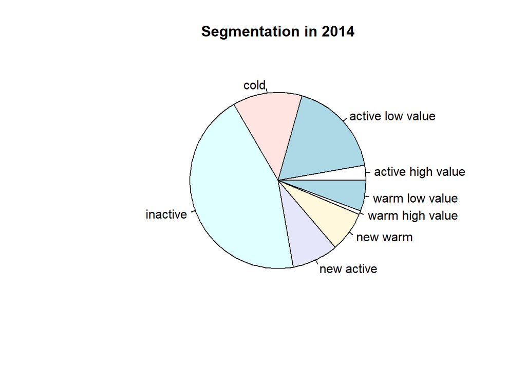

```r
pie(table(customers_2014$segment), main="Segmentation in 2014") #2014
```

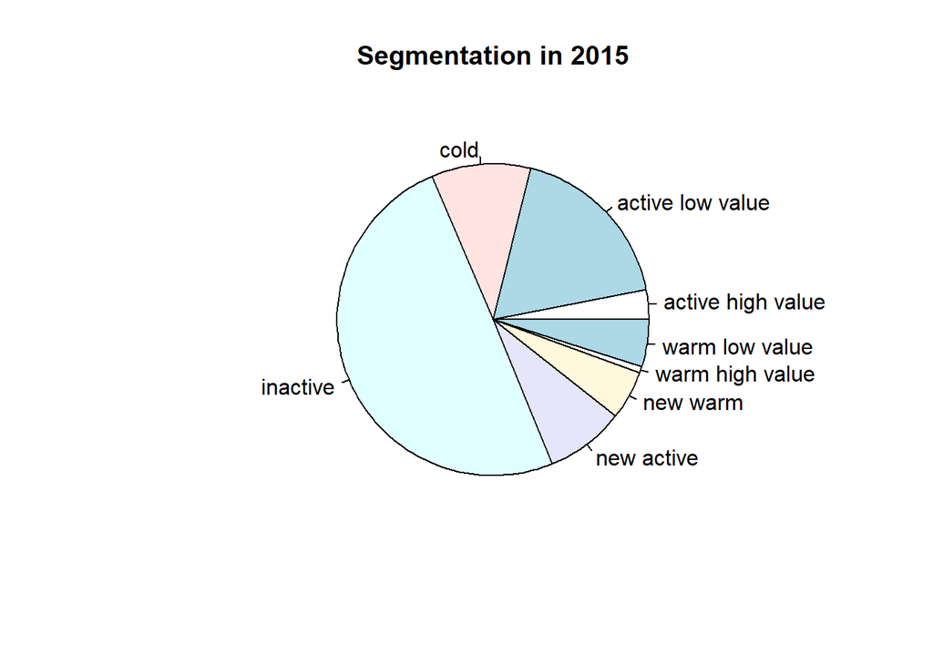

```r
pie(table(customers_2015$segment), main="Segmentation in 2015") #2015
```

*Part 5: Calculating Average revenue per Segment for the year 2015*

```r
revenue_2015 = sqldf("SELECT customer_id, SUM(purchase_amount) AS 'revenue_2015'
                      FROM Seg1
                      WHERE year_of_purchase = 2015
                      GROUP BY customer_id")
View(revenue_2015)
summary(revenue_2015)
```

```
##   customer_id      revenue_2015
##  Min.   :    80   Min.   :   5.00
##  1st Qu.:104105   1st Qu.:  30.00
##  Median :185495   Median :  50.00
##  Mean   :167782   Mean   :  88.62
##  3rd Qu.:246058   3rd Qu.:  85.00
##  Max.   :264200   Max.   :4500.00
```

*Now Merging with the 2014 DATA in order to compare how the customers per Segment in the year 2014 spent in year 2015*

```r
#merging average revenue of 2015 customer with original table
actual = merge(customers_2015, revenue_2015, all.x = TRUE)
actual$revenue_2015[is.na(actual$revenue_2015)] = 0
#avg revenue per customer per segment
aggregate(x = actual$revenue_2015, by = list(customers_2015$segment), mean)
```

```
##             Group.1         x
## 1 active high value 323.56894
## 2  active low value  52.30604
## 3              cold   0.00000
## 4          inactive   0.00000
## 5        new active  79.16614
## 6          new warm   0.00000
## 7   warm high value   0.00000
## 8    warm low value   0.00000
```

```r
#merging 2014 and 2015 data
forward = merge(customers_2014, revenue_2015, all.x = TRUE)
forward$revenue_2015[is.na(forward$revenue_2015)] = 0
View(forward)
```

*Part 6: Finding Average Revenue Per Segment in the year 2015*

```r
r = aggregate(x = forward$revenue_2015, by = list(customers_2014$segment), mean)
#arranging it in decreasing order
r = r[order(r$x, decreasing = TRUE), ]
print(r)
```

```
##             Group.1          x
## 1 active high value 254.077895
## 7   warm high value 114.459459
## 2  active low value  41.896556
## 5        new active  31.046625
## 8    warm low value  13.494770
## 3              cold   6.108221
## 6          new warm   5.064000
## 4          inactive   2.949466
```

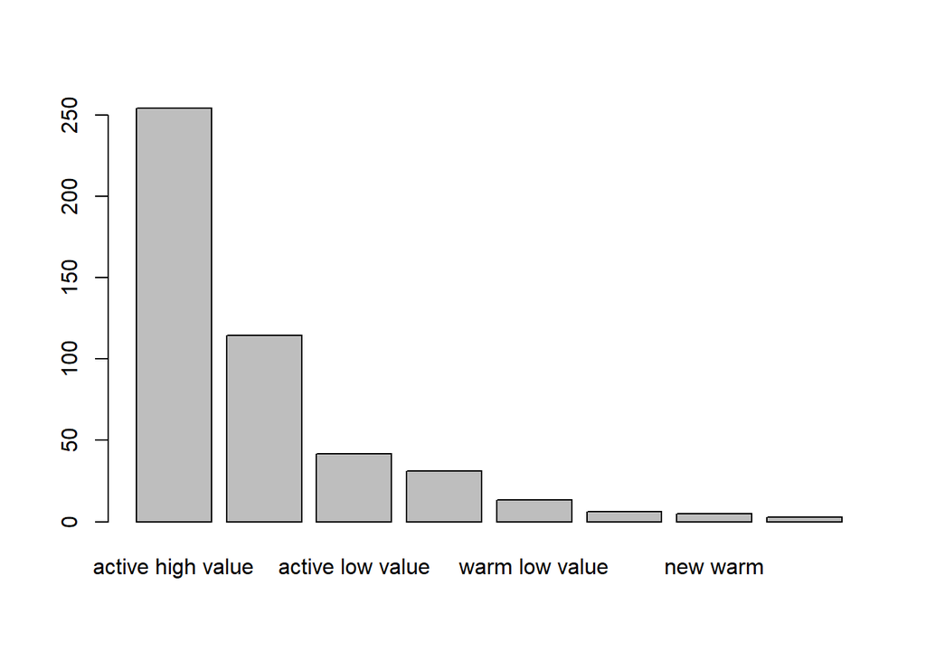

```r
barplot(r$x, names.arg = r$Group.1)
```